# Mais sobre o formato de distribuições

Além de localizar centro e extremos nas distribuições valores, algumas outras características úteis para descrever uma distribuição são:

1. Quão assimétrica ela é?
2. Quão concentrada ou espalhada ela é?
3. Ela tem uma cauda? Duas? Longas?

Os dados de clima tem exemplos de distribuições mais e menos simétricas e mais e menos concentradas.

```r
climas = read_csv(here::here("data/clima_cg_jp-semanal.csv"),
                  col_types = "cTdddddd")

glimpse(climas)
```

```
## Observations: 2,748
## Variables: 8
## $ cidade <chr> "Campina Grande", "Campina Grande", "Campina Grande", "Campi...
## $ semana <dttm> 1992-12-27, 1993-01-03, 1993-01-10, 1993-01-31, 1993-02-07,...
## $ tmedia <dbl> 26.13333, 26.11905, 25.76667, 25.74000, 26.31429, 26.28571, ...
## $ tmax   <dbl> 30.4, 32.4, 32.2, 32.0, 32.7, 32.7, 32.3, 32.3, 32.1, 31.2, ...
## $ tmin   <dbl> 20.7, 19.3, 19.7, 19.9, 19.6, 20.0, 20.4, 21.2, 19.0, 19.0, ...
## $ chuva  <dbl> 0.0, 0.0, 0.0, 0.4, 0.3, 0.0, 4.9, 0.0, 0.0, 6.1, 0.4, 1.2, ...
## $ mes    <dbl> 12, 1, 1, 1, 2, 2, 2, 2, 10, 11, 11, 11, 11, 12, 12, 12, 12,...
## $ ano    <dbl> 1992, 1993, 1993, 1993, 1993, 1993, 1993, 1993, 1993, 1993, ...
```

## Temperatura x chuva em CG

Repare como a distribuição de quantidade de chuvas semanal é muito mais assimétrica que a de temperaturas médias. Ela tem uma assimetria com cauda maior à direita. E longa.

Abaixo colocamos várias visualizações das distribuições para você explorar como os formatos diferentes aparecem em diferentes visualizações.

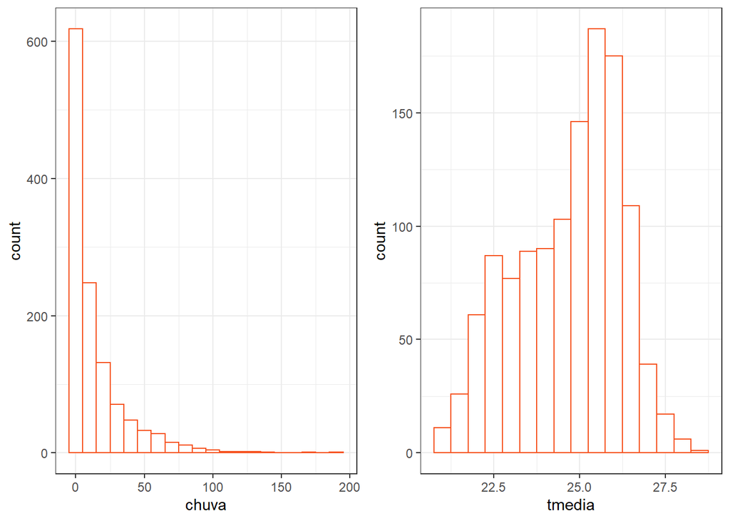

```r
# histograma
cg = climas %>%
    filter(cidade == "Campina Grande")

hist_chuvas = cg %>%
    ggplot(aes(x = chuva)) +
    geom_histogram(binwidth = 10, color = "#F6511D", fill = "white")

hist_temperatura = cg %>%
    ggplot(aes(x = tmedia)) +
    geom_histogram(binwidth = .5, color = "#F6511D", fill = "white")

grid.arrange(hist_chuvas, hist_temperatura, ncol = 2)
```

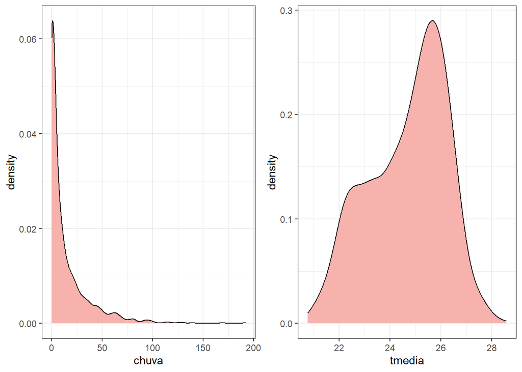

```r
# densidade
dens_chuvas = cg %>%
    ggplot(aes(x = chuva)) +
    geom_density(fill = "#F7B2AD")

dens_temperatura = cg %>%
    ggplot(aes(x = tmedia)) +
    geom_density(fill = "#F7B2AD")

grid.arrange(dens_chuvas, dens_temperatura, ncol = 2)
```

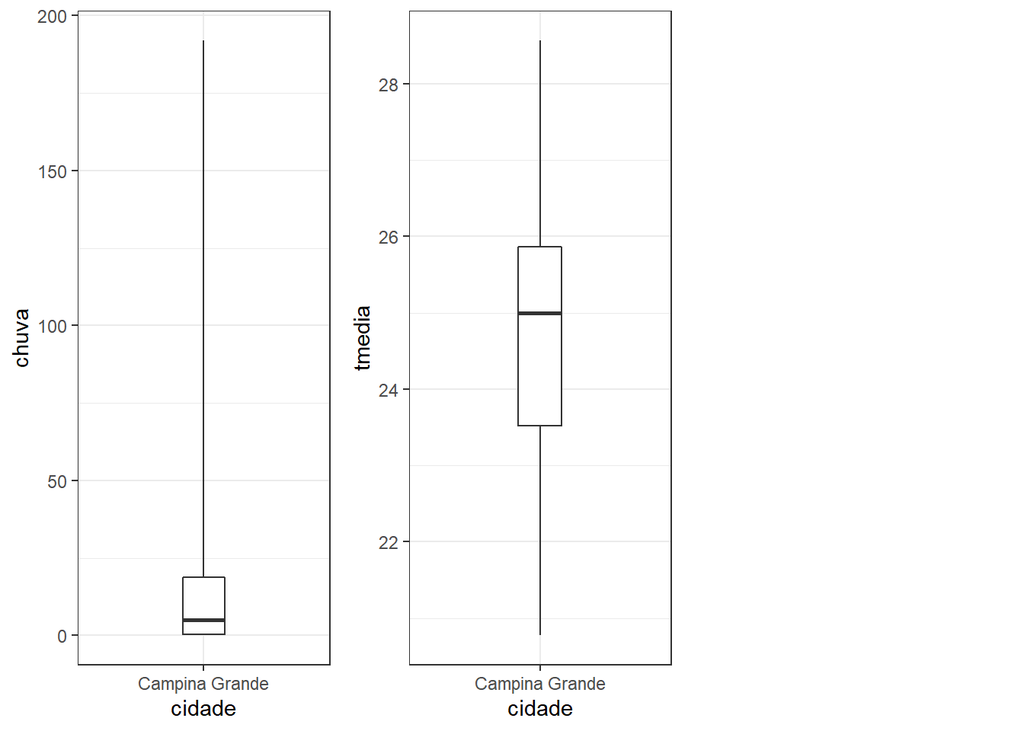

```r
# boxplot
box_chuvas = cg %>%
    ggplot(aes(x = cidade, y = chuva)) +
    geom_boxplot(coef = 1000, width = .2)

box_temperatura = cg %>%
    ggplot(aes(x = cidade, y = tmedia)) +
    geom_boxplot(coef = 1000, width = .2)

grid.arrange(box_chuvas, box_temperatura, ncol = 3)
```

A disribuição de temperaturas médias nem é tão simétrica assim, tendo uma cauda maior à esquerda. Às vezes se diz que há uma assimetria (ou skewness) positiva em casos como o das chuvas, e negativa no caso da temperatura média.

Interessante, dependendo da época em que olhemos para CG, a distribuição é assimétrica com cauda à esquerda ou à direita:

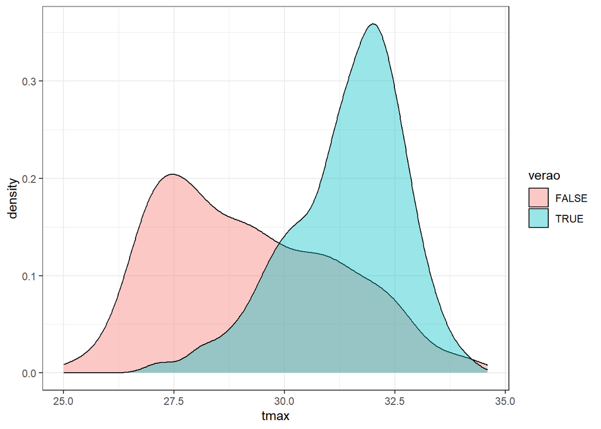

```r
cg %>%
    mutate(verao = mes > 8 | mes < 3) %>%
    ggplot(aes(x = tmax, fill = verao)) +
    geom_density(alpha = .4)
```

Um exercício legal é procurar padrões nos gráficos de densidade (ou histogramas) das temperaturas em diferentes anos:

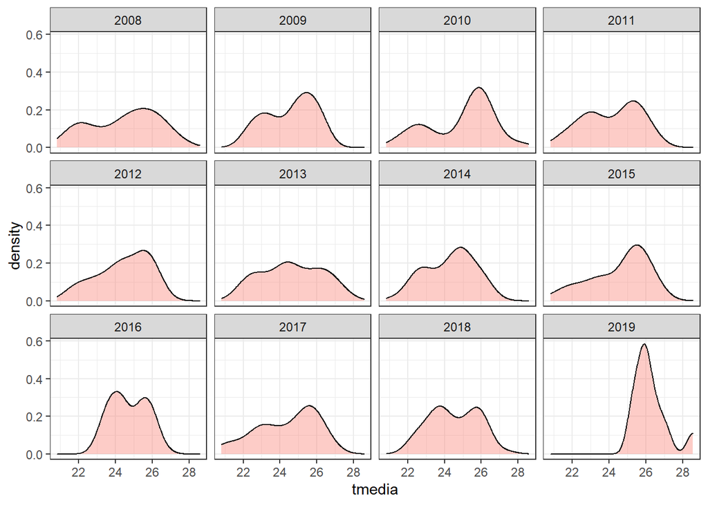

```r
cg %>%
    filter(ano >= 2008) %>%
    ggplot(aes(x = tmedia)) +
    geom_density(alpha = .4, fill = "salmon") +
    facet_wrap(~ ano)
```

O mesmo pode ser feito com boxplot também. Compare o que você vê em um e outro.

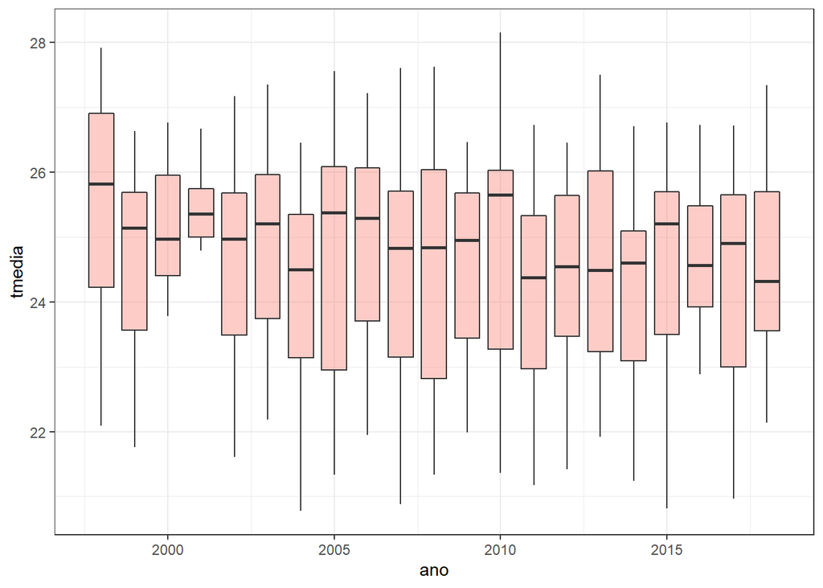

```r
cg %>%
    filter(ano >= 1998, ano < 2019) %>%
    ggplot(aes(x = ano, y = tmedia, group = ano)) +
    geom_boxplot(alpha = .4, fill = "salmon", coef = 1000)
```

Para a concentração de valores em torno da moda, embora ambas sejam bastante concentradas, a chuva em CG é bem mais concentrada em torno do zero que a chuva em JP:

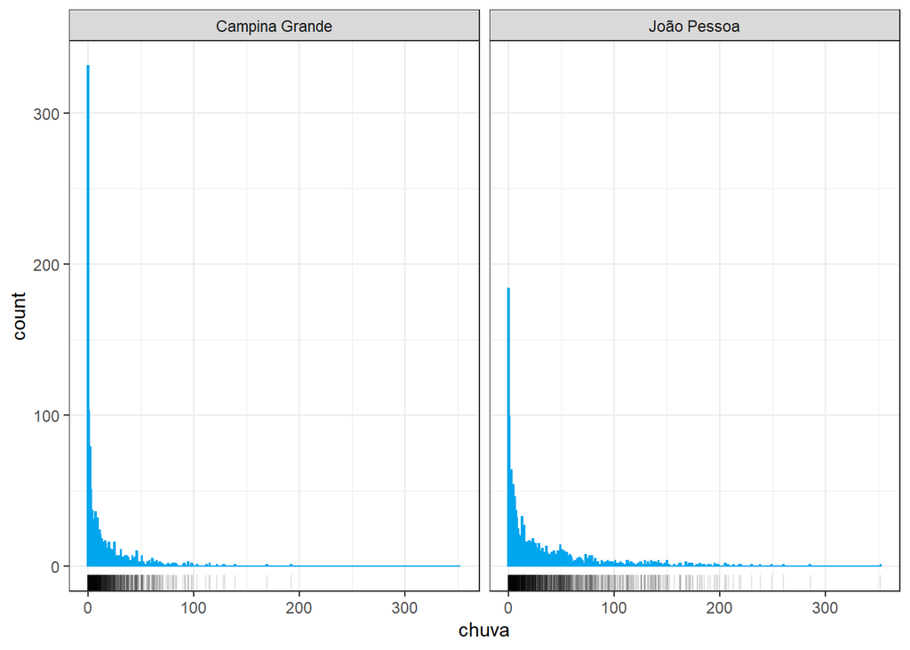

```r
climas %>%
    ggplot(aes(x = chuva)) +
    geom_histogram(binwidth = 1, color = "#00A6ED", fill = "white") +
    geom_rug(alpha = .1) +
    facet_wrap(~ cidade)
```

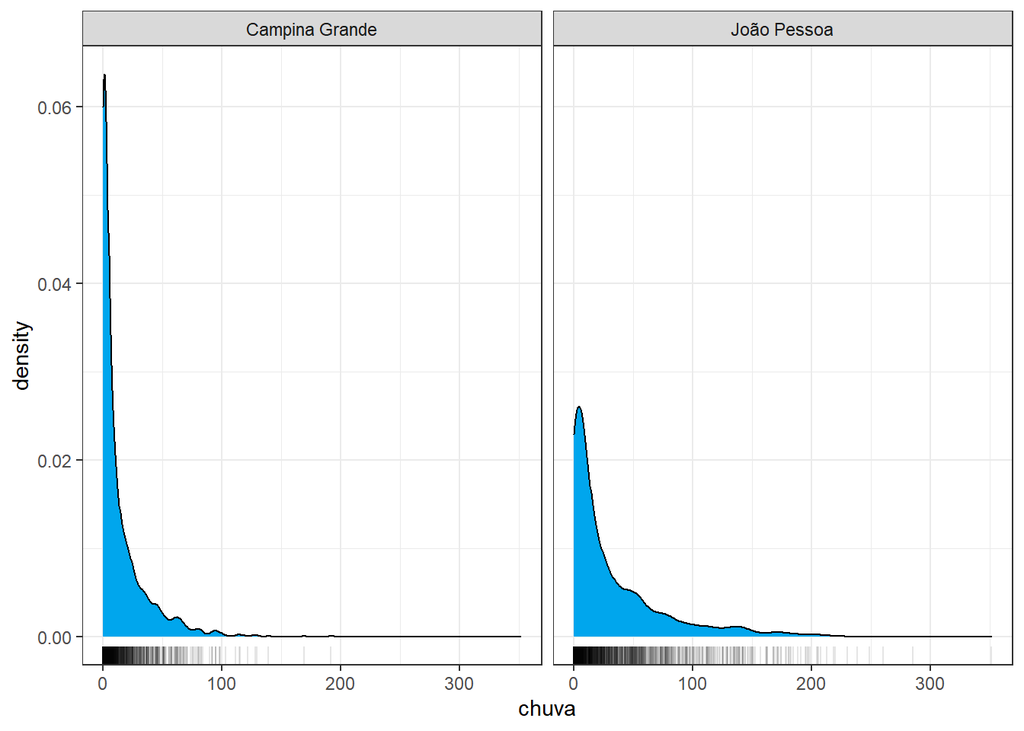

```r
climas %>%
    ggplot(aes(x = chuva)) +
    geom_density(fill = "#00A6ED") +
    geom_rug(alpha = .1) +
    facet_wrap(~ cidade)
```

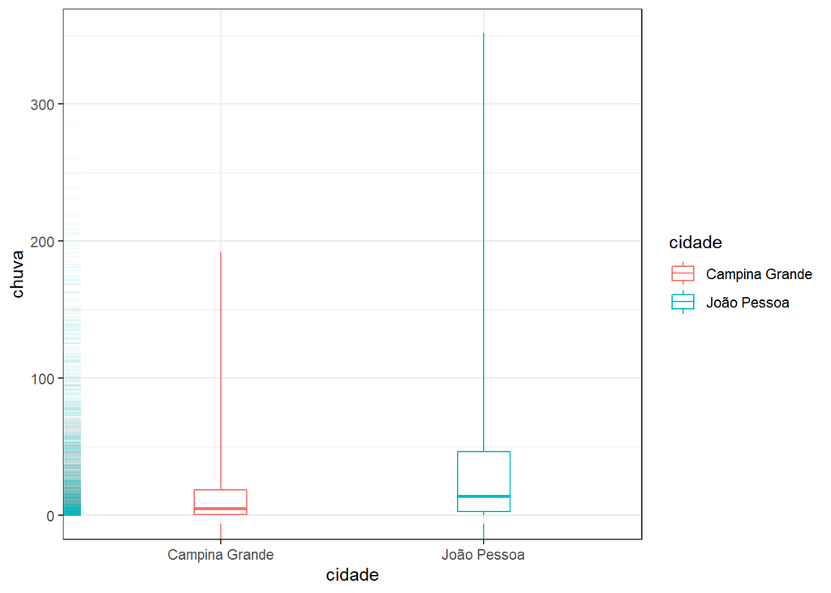

```r
climas %>%
    ggplot(aes(x = cidade, y = chuva, color = cidade)) +
    geom_boxplot(coef = 1000, width = .2) +
    geom_rug(alpha = .05)
```

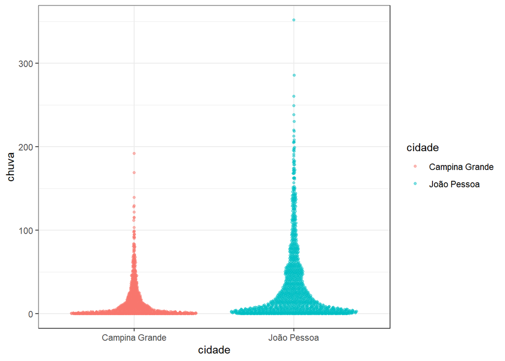

```r
climas %>%
    ggplot(aes(x = cidade, y = chuva, color = cidade)) +
    geom_quasirandom(alpha = .5, size = 1)
```